# CH5 : Desion Trees & Rondom Forests

TP5 : Regression tree

> In this practical work, we will build some decision trees for both regression and classification problems. Note that there are many packages to do this in `R` . The tree package is the basic package to do so, while the `rpart17` package seems more widely suggested and provides better plotting features. So we will use the `rpart` package.

# Question 1

Load the Boston dataset from `MASS` package. Split the dataset randomly in half.

```r
library(MASS)
library(caTools)
set.seed(18)
Boston_idx = sample(1:nrow(Boston), nrow(Boston) / 2)
# You don't know what we just did?
# open the documentation of the function sample by
# writing ?sample in the R console.
# Note that this is one of the ways to split it randomly and
#it is not necessary the best.
Boston_train = Boston[Boston_idx,]
Boston_test  = Boston[-Boston_idx,]
```

# Question 2

Fit a regression tree to the training data using the `rpart()` function from the `rpart` package. Name the tree `Boston_tree`.

```r
library(rpart)
Boston_tree = rpart(medv ~.,data=Boston_train)
```

> La fonction rpart realise par defaut une estimation des performances de l’arbre par validation croisee a 10 blocs pour chaque niveau de simplification pertinent. Le nombre de blocs se regle au moment de la construction de l’arbre grace au parametre xval de rpart.control

# Question 3

Plot the obtained tree using the following code

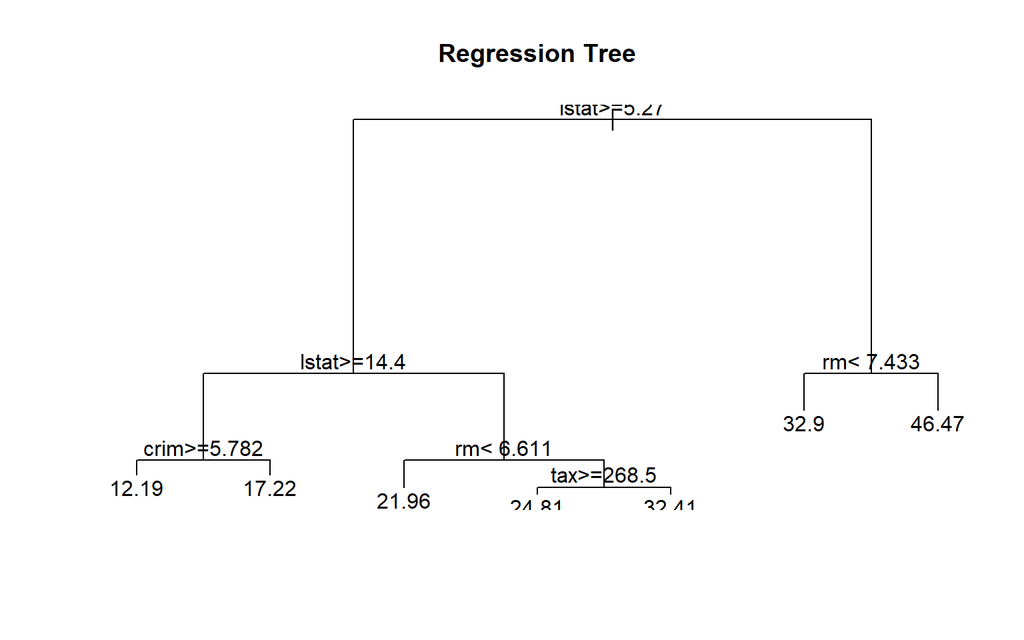

```r
plot(Boston_tree)
text(Boston_tree, pretty = 0)
title(main = "Regression Tree")
```

# Question 4

A better plot can be obtained using the `rpart.plot18` package. Re-plot the tree using it. You can use the `rpart.plot()` function which by default, when the output is continuous, each node shows: the predicted value, and the percentage of observations in the node. You can also use the `prp()` function

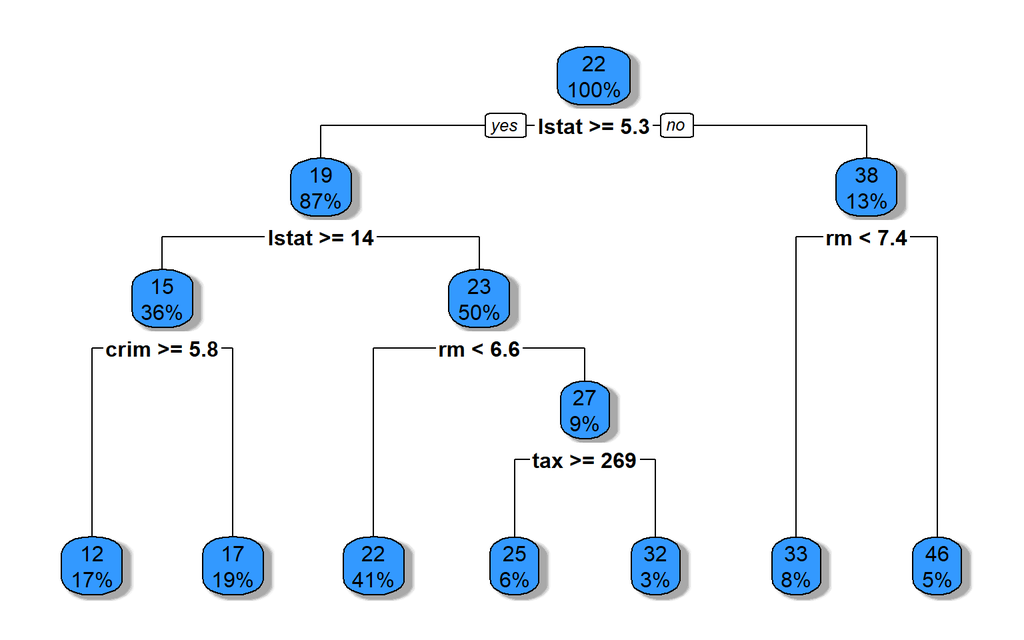

```r
#install.packages("rpart.plot")
library(rpart.plot)
rpart.plot(Boston_tree,shadow.col = "darkgrey",box.palette = "#3399FF")
```

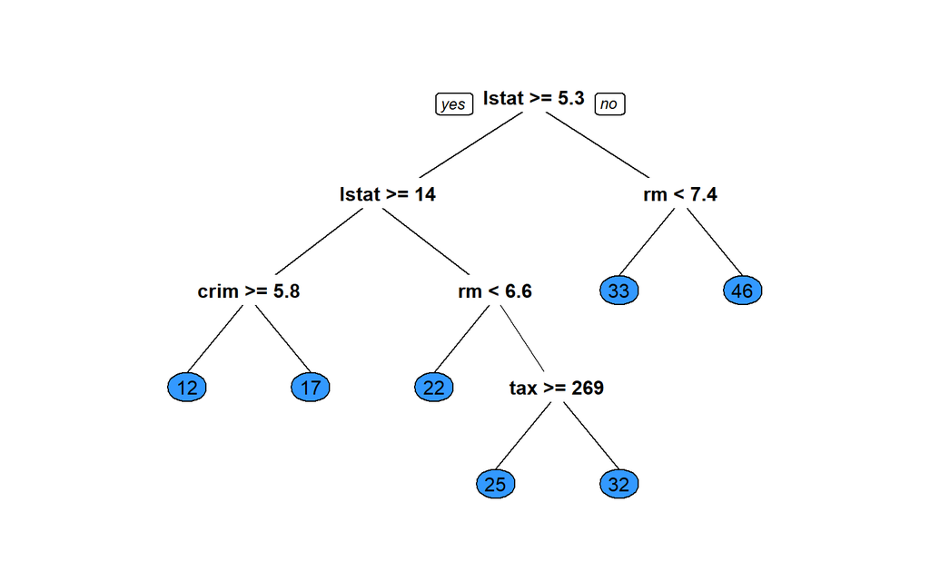

```r
prp(Boston_tree,branch = 0,box.palette = "#3399FF",legend.x = 'Tree')
```

# Question 5

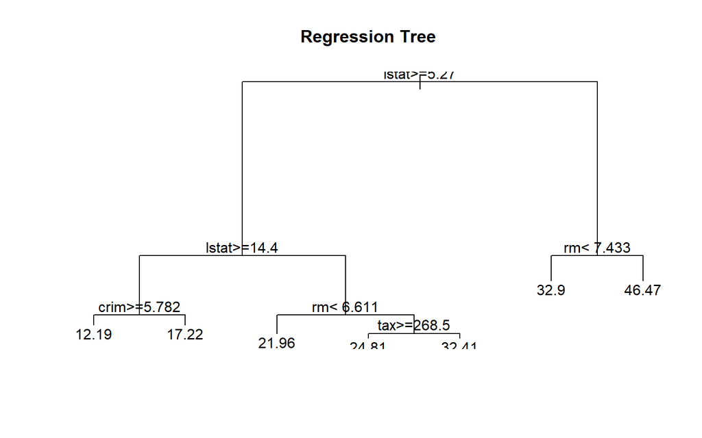

```r
plot(Boston_tree)
text(Boston_tree, pretty = 0)
title(main = "Regression Tree")
```

> Achieved at :

```r
index_best <- which.min(Boston_tree$cptable[,"xerror"])
index_best
```

```
## 7
## 7
```

```r
7
```

```
## [1] 7
```

> And equal to

```r
Boston_tree$cptable[index_best,"xerror"]
```

```
## [1] 0.3051705
```

```r
# 0.3051705
```

> With standard deviation :

```r
Boston_tree$cptable[index_best,"xstd"]
```

```
## [1] 0.0561795
```

```r
# 0.0561795
```

> So, we want the smallest tree with xerror less than 0.30517 + 0.05618 = 0.361

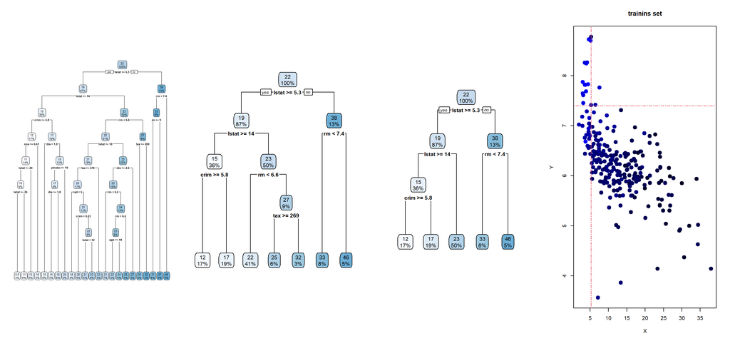

```r
par(mfrow=c(1,4))

Boston_tree = rpart(medv ~ ., data = Boston_train, cp=-1)
rpart.plot(Boston_tree)

Boston_tree = rpart(medv ~ ., data = Boston_train)
rpart.plot(Boston_tree)

Boston_tree <- prune(Boston_tree,cp= 0.02629297)
rpart.plot(Boston_tree)


X <- Boston_train$lstat
Y <- Boston_train$rm
Z <- Boston_train$medv
ZZ = abs(Z)/max(Z)
plot(Y~X, col=rgb(0, 0, ZZ),lwd = 4, main="trainins set")
abline(v=5.3,lty=6,col=2)
abline(h=7.4,lty=6,col=2)
```

> As a rule of thumb, it is best to prune a decision tree using the cp of smallest tree that is within one standard deviation of the tree with the smallest xerror.

# Question 6

Write a function that returns the `RMSE` of two vectors.

```r
RMSE = function(actual, predicted){
    return (sqrt(sum((predicted-actual)**2)/length(predicted)))
}
```

# Question 7

Use the function `predict()` to predict the response on the test set. Then calculate the RMSE obtained with tree model

```r
tree_Predict=predict(Boston_tree,newdata=Boston_test)
rmse_singleTree = RMSE(Boston_test$medv,tree_Predict)
rmse_singleTree
```

```
## [1] 5.958882
```

# Question 8

Fit a linear regression model on the training set. Then predict the response on the test set using the linear model. Calculate the `RMSE` and compare the performance of the tree and the linear regression model.

```r
LinearModel = lm(medv ~ ., data = Boston_train)
LinearPrediction = predict(LinearModel, Boston_test)
rmseLinear = RMSE(Boston_test$medv, LinearPrediction)
rmseLinear
```

```
## [1] 5.016083
```

# Question 9

You can visually compare the performance of both models by plotting the Actual (reality) response values against the predicted values. The model with closer points are to the diagonal (y=x) line is the better one. You can try to reproduce the figure below.

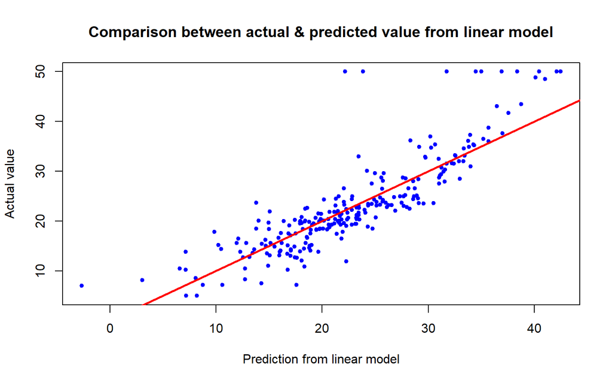

```r
#par(mfrow=c(1,2))
plot(LinearPrediction,Boston_test$medv,
            col='blue',
            xlab = "Prediction from linear model",
            ylab = "Actual value", cex=1,
            pch=20)
title('Comparison between actual & predicted value from linear model')
abline(0,1, col='red', lwd=2.5)
```

# Question 10

Fit a bagged model, using the randomForest() function from the `randomForest` package.

```r
#install.packages("randomForest")
library(randomForest)
baggedmodel=randomForest(medv~.,data = Boston_train, mtry=13) #Number of predictors = 13
baggedmodel$importance
```

```
##         IncNodePurity
## crim       636.381857
## zn          34.395256
## indus      102.270173
## chas         9.860034
## nox        474.205768
## rm        4214.308402
## age        225.169288
## dis        481.820529
## rad         61.450213
## tax        474.233900
## ptratio    151.976134
## black      274.468667
## lstat    12375.150925
```

# Question 11

Predict the response on the test set using the bagging model. Calculate the `RMSE`. Is the performance of the model better than linear regression or a simple tree.

```r
baggedmodel_Predict=predict(baggedmodel, Boston_test)
#table(baggedmodel_Predict,Boston_test$medv) it is not a categorical variable so multiple table is not interesting
rmse_bagged = RMSE(Boston_test$medv,baggedmodel_Predict)
rmse_bagged
```

```
## [1] 3.894497
```

# Question 12

Fit a random forest on the training set and compare its performance with the previous models by calculating the predictions and the `RMSE`.

```r
rdmForestmodel=randomForest(medv~.,data = Boston_train, mtry=4)
rdmForestmodel_Predict=predict(rdmForestmodel, Boston_test)
rmse_rdmForest = RMSE(Boston_test$medv,rdmForestmodel_Predict)
rmse_rdmForest
```

```
## [1] 4.166955
```

# Question 13

Use the function `importance()` from the `randomForest` package to see the most important predictors in the obtained random forest model. What are the three most important predictors? Did you find the same results when you selected the best predictors for the linear regression model during session 2

```r
rdmForestmodel$importance
```

```
##         IncNodePurity
## crim        1316.3228
## zn           121.1325
## indus       1584.0335
## chas         104.9439
## nox         1120.6633
## rm          4736.8404
## age          468.1450
## dis          921.3306
## rad          214.3600
## tax          791.7973
## ptratio     1299.7201
## black        445.3433
## lstat       6305.2221
```

# Question 14

Plot the importance of the predictors to the model using the `varImpPlot()` function.

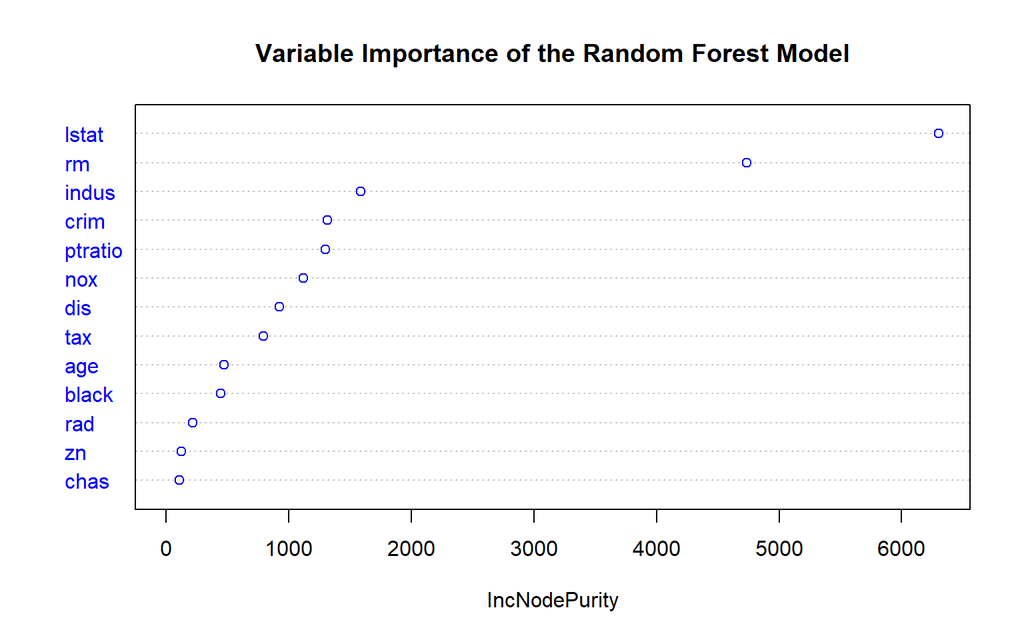

```r
varImpPlot(rdmForestmodel, col = 'Blue', main = "Variable Importance of the Random Forest Model")
```

# Question 15

Using the `gbm()` function like following, fit a boosted model on the training set. Then compare its performance with the previous models by calculating the predictions and the `RMSE`

```r
#install.packages("gbm")
library(gbm)
Boston_boost = gbm(medv ~ ., data = Boston_train, distribution = "gaussian",
                    n.trees = 5000, interaction.depth = 4, shrinkage = 0.01)
Boston_boost_Predict=predict(Boston_boost, Boston_test)
```

```
## Using 5000 trees...
```

```r
rmse_boost = RMSE(Boston_test$medv,Boston_boost_Predict)
rmse_boost
```

```
## [1] 3.684739
```

# Question 16

Show the summary of the boosted model. A figure of the variable importance will be shown.

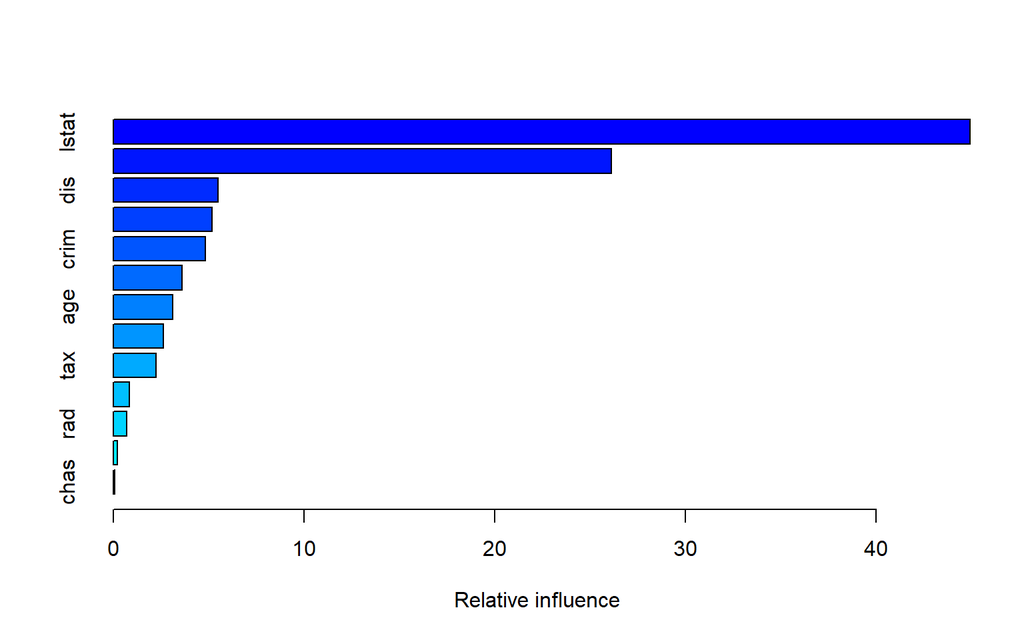

```
##             var     rel.inf
## lstat     lstat 44.92605206
## rm           rm 26.11539591
## dis         dis  5.51013905
## nox         nox  5.18798916
## crim       crim  4.81828593
## black     black  3.59678002
## age         age  3.12917499
## ptratio ptratio  2.62747806
## tax         tax  2.23025414
## indus     indus  0.85939208
## rad         rad  0.70032866
## zn           zn  0.21933344
## chas       chas  0.07939649
```

```r
summary(Boston_boost)
```

# Question 17

Construct a final plot to compare the four trained models

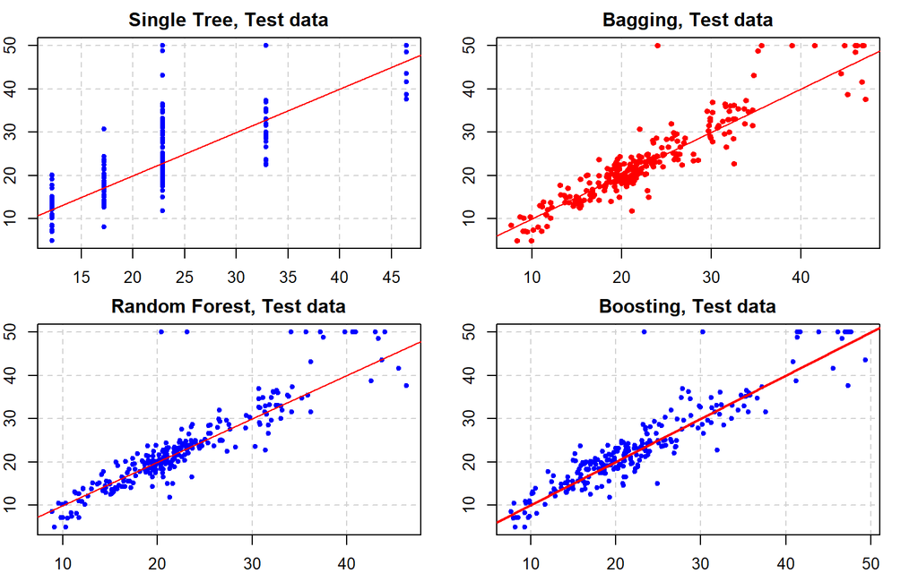

```r
par(mfrow=c(2,2))
par(mar = rep(2, 4))

plot(tree_Predict,Boston_test$medv,
            col='blue',
            xlab = "Predicted",
            ylab = "Actual value",
            pch = 20,
            panel.first = grid(lty=2)
            )
title('Single Tree, Test data')
abline(0,1, col='red')

plot(baggedmodel_Predict,Boston_test$medv,
            col='red',
            xlab = "Predicted",
            ylab = "Actual value", cex=1.1,
            pch=20, panel.first = grid(lty=2))
title('Bagging, Test data')
abline(0,1, col='red')

plot(rdmForestmodel_Predict,Boston_test$medv,
            col='blue',
            xlab = "Predicted",
            ylab = "Actual value",
            pch=20,
            panel.first = grid(lty=2)
     )
title('Random Forest, Test data')
abline(0,1, col='red')

plot(Boston_boost_Predict,Boston_test$medv,
            col='blue',
            xlab = "Predicted",
            ylab = "Actual value",
            cex=1,
            pch=20,
            panel.first = grid(lty=2)
     )
title('Boosting, Test data')
abline(0,1, col='red', lwd=2)
```

# XGBoost : Extreme Gradient Boosting

> XGBoost is an optimized distributed gradient boosting library designed to be highly efficient, flexible and portable. It implements machine learning algorithms under the Gradient Boosting framework. XGBoost provides a parallel tree boosting (also known as GBDT, GBM) that solve many data science problems in a fast and accurate way. Since its introduction, this algorithm has not only been credited with winning numerous Kaggle competitions but also for being the driving force under the hood for several cutting-edge industry applications

```r
#library(xgboost)
#indexes = createDataPartition(Boston$medv, p = .85, list = F)
#train = Boston[indexes, ]
#test = Boston[-indexes, ]

#train_x = data.matrix(train[, -13])
#train_y = train[,13]

#test_x = data.matrix(test[, -13])
#test_y = test[, 13]

#xgb_train = xgb.DMatrix(data = train_x, label = train_y)
#xgb_test = xgb.DMatrix(data = test_x, label = test_y)

#xgbc = xgboost(data = xgb_train, max.depth = 2, nrounds = 50)
#print(xgbc)

#Boston_xgboost_pred = predict(xgbc, xgb_test)

#rmse(Boston_xgboost_pred, test_y)
```